# Data624_HW6

Alexis Mekueko

10/23/2021

[Github Link](https://github.com/asmozo24/Data624_HW6) [Web Link](https://rpubs.com/amekueko/820388)

## Exercise 1.

Figure 9.32 shows the ACFs for 36 random numbers, 360 random numbers and 1,000 random numbers. a. Explain the differences among these figures. Do they all indicate that the data are white noise? Series: x1, There is one significant spike at lag 12. Other Series:x2, Series: x3 don’t have significant spike. The bandwidth keeps getting narrow from x1 to x3.Yes, they all indicate that the data are white noise. These figures meet the condition of white noise: A time series is white noise if the variables are independent and identically distributed with a mean of zero. This means that all variables have the same variance (sigma^2) and each value has a zero correlation with all other values in the series. There is no clear pattern on these figures.

Why are the critical values at different distances from the mean of zero? Why are the autocorrelations different in each figure when they each refer to white noise? critical values of ±1.96/√T, T is the length of time series. On these figures, as T get bigger, the bandwidth gets narrow. This explains the critical values at different distances and autocorrelation different in each figure.

## Exercise 2.

A classic example of a non-stationary series are stock prices. Plot the daily closing prices for Amazon stock (contained in gafa_stock), along with the ACF and PACF. Explain how each plot shows that the series is non-stationary and should be differenced.

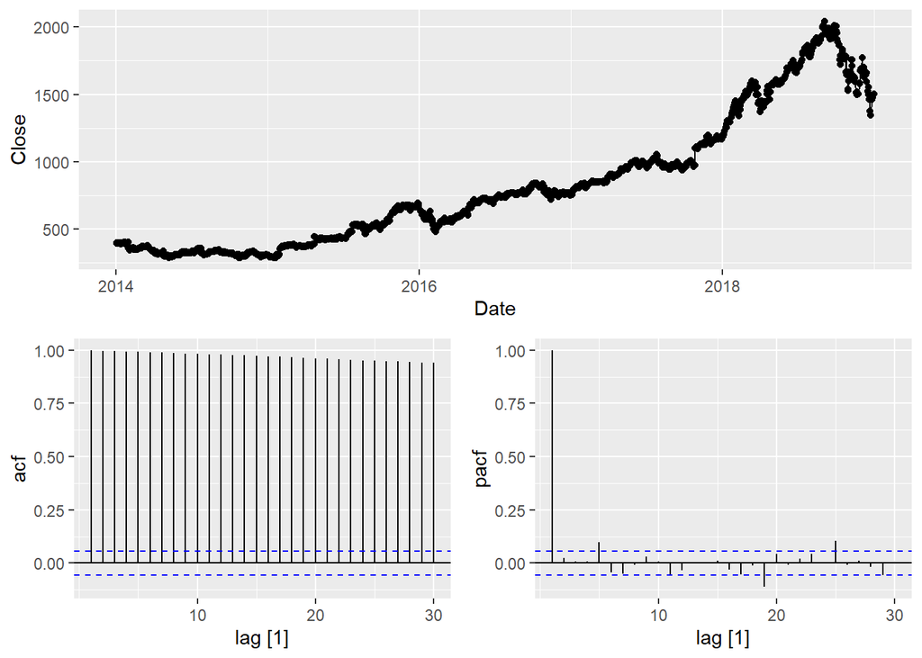

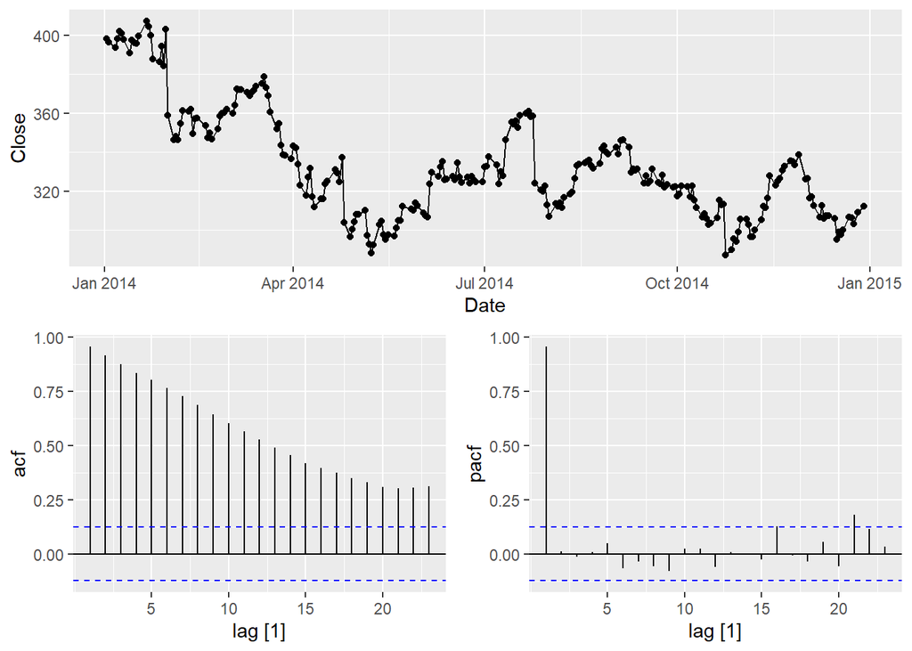

## Exercise 3

For the following series, find an appropriate Box-Cox transformation and order of differencing in order to obtain stationary data. a. Turkish GDP from global_economy.

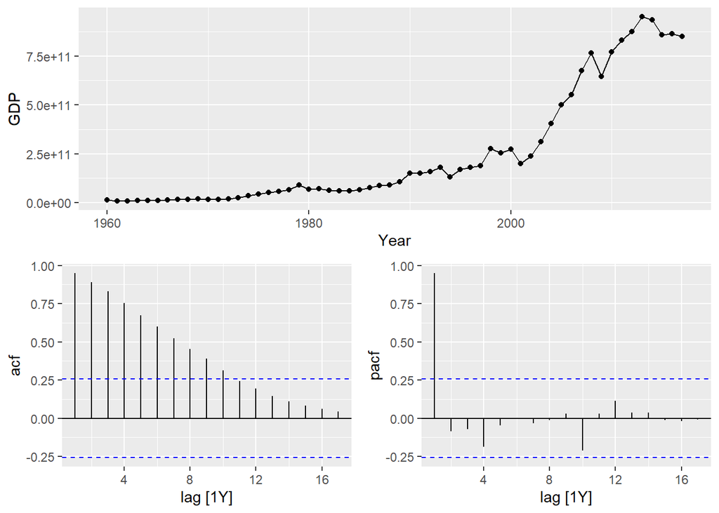

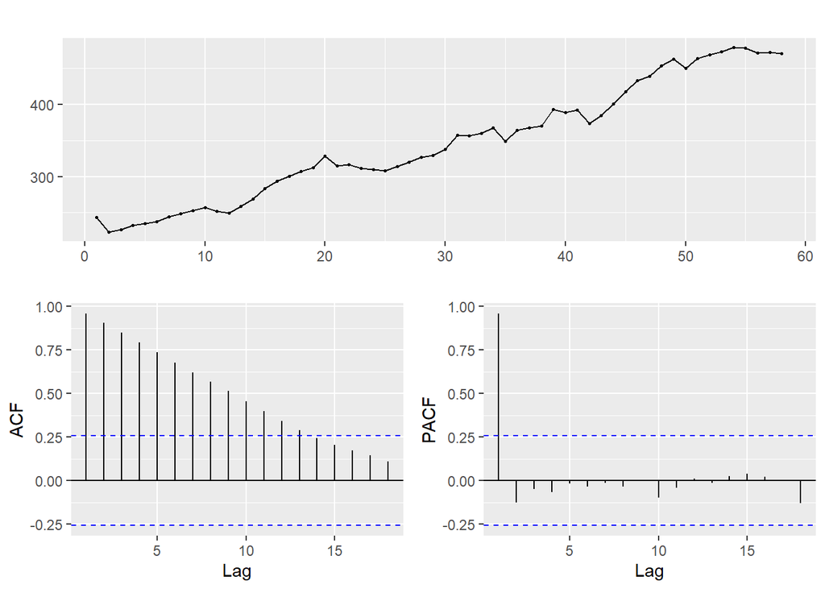

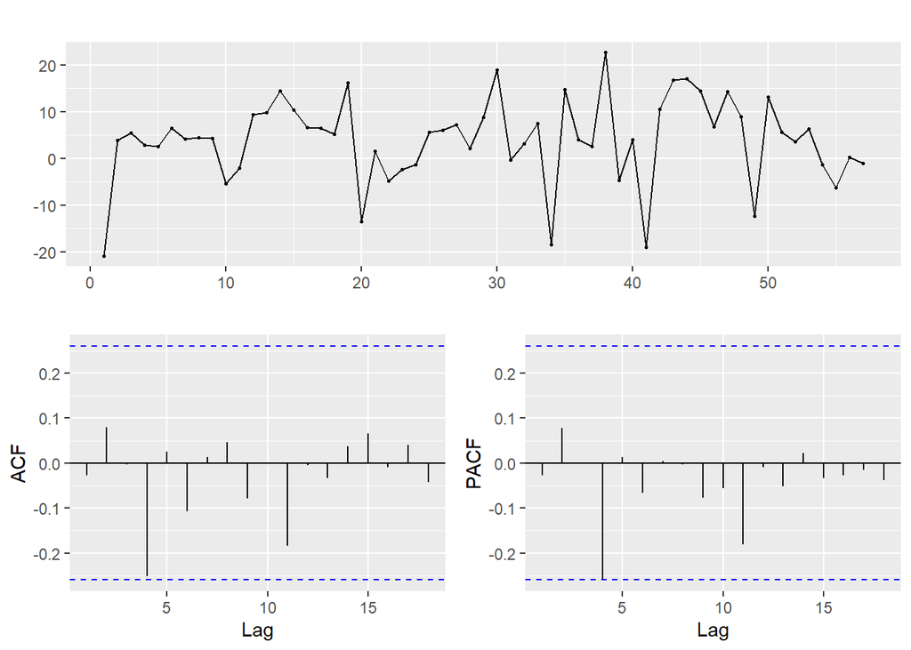

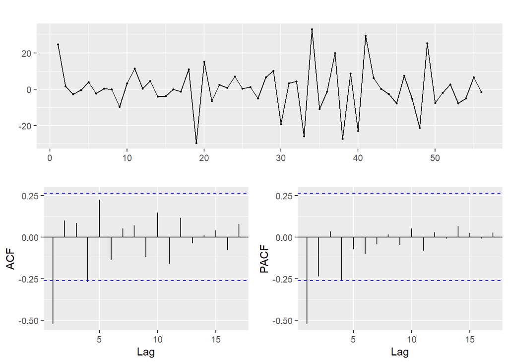

```
##
## #######################
## # KPSS Unit Root Test #
## #######################
##
## Test is of type: mu with 3 lags.
##
## Value of test-statistic is: 0.0889
##
## Critical value for a significance level of:
##                 10pct  5pct 2.5pct  1pct
## critical values 0.347 0.463  0.574 0.739
```

Lambda = 0.1571804 order of differencing in order = 2 Performs the KPSS unit root test, where the Null hypothesis is stationarity. Based on this test, Value of test-statistic is: 0.0889 …Turkey_GDP is stationary.

2. Accommodation takings in the state of Tasmania from aus_accommodation.

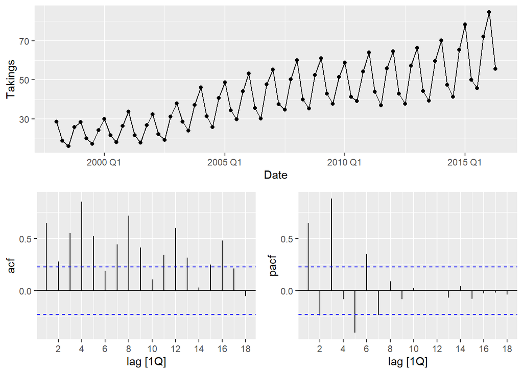

ACF has many spikes, time series plot has upwward trend line.

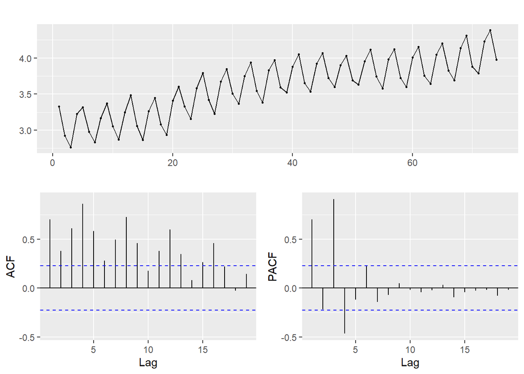

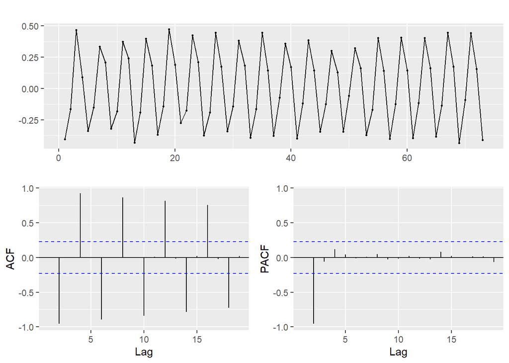

```
##
## #######################
## # KPSS Unit Root Test #
## #######################
##
## Test is of type: mu with 3 lags.
##
## Value of test-statistic is: 0.2573
##
## Critical value for a significance level of:
##                 10pct  5pct 2.5pct  1pct
## critical values 0.347 0.463  0.574 0.739
```

Lambda = -0.005076712 order of differencing in order = 1 Based on the KPSS test, Value of test-statistic is: 0.2573 Accommodation takings in the state of Tasmania data is stationary.

3. Monthly sales from souvenirs.

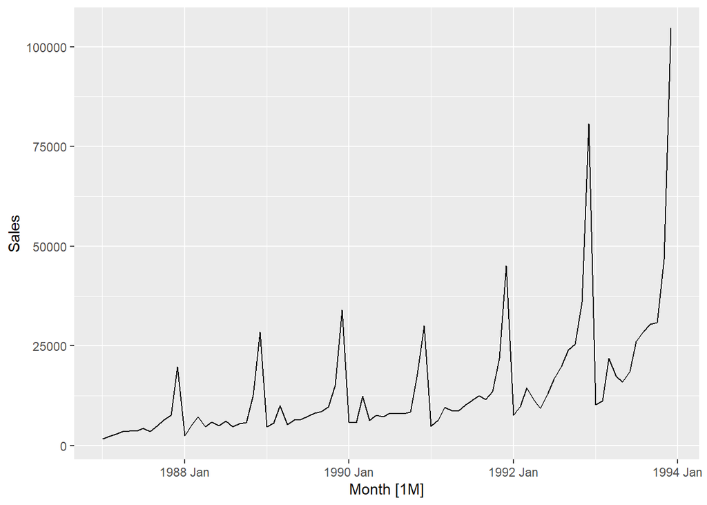

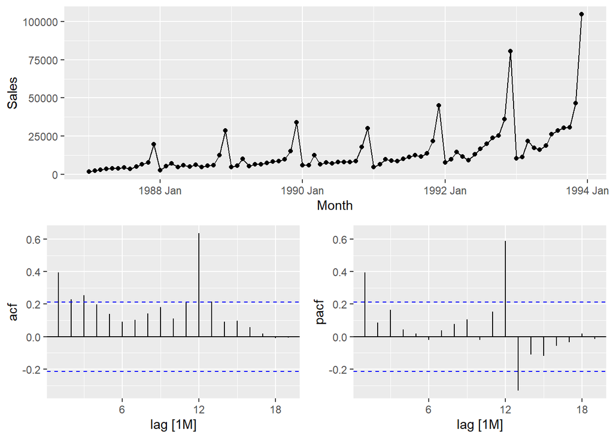

The time series of souvenirs looks like moving horizontal with a peak at the end of cycle (this looks like a stationany data). However, these peaks seem to gaining magnitude from year to year. Meaning, we might have a non-stationary data(not 100% sure).

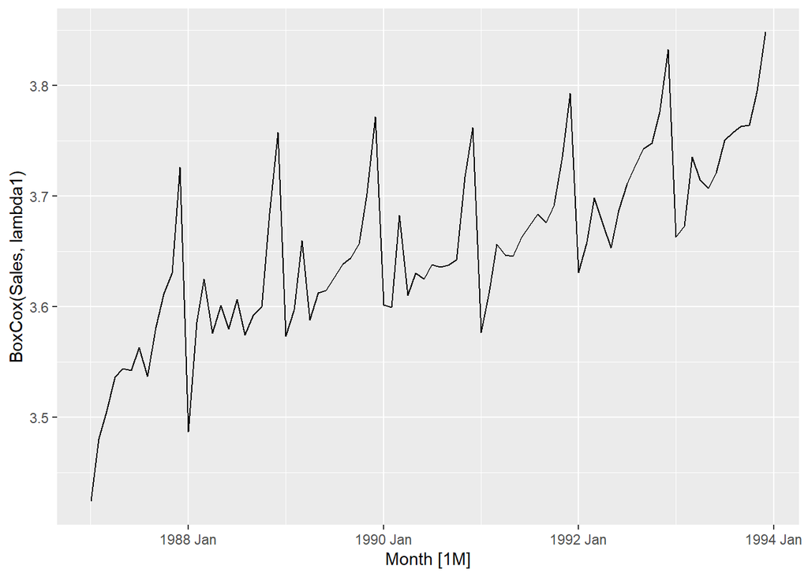

```
##
## #######################
## # KPSS Unit Root Test #
## #######################
##
## Test is of type: mu with 3 lags.
##
## Value of test-statistic is: 0.0615
##
## Critical value for a significance level of:
##                 10pct  5pct 2.5pct  1pct
## critical values 0.347 0.463  0.574 0.739
```

## Exercise 5

For your retail data (from Exercise 8 in Section 2.10), find the appropriate order of differencing (after transformation if necessary) to obtain stationary data.

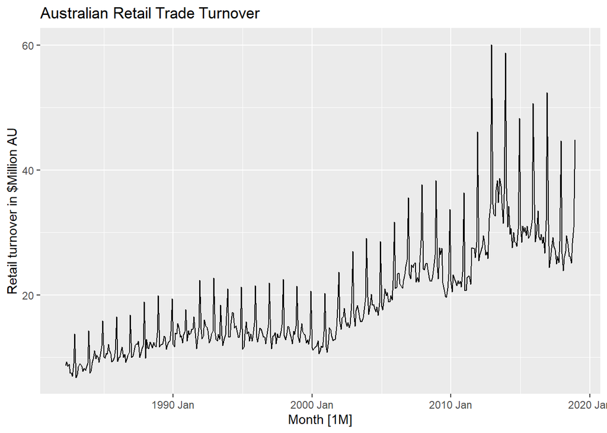

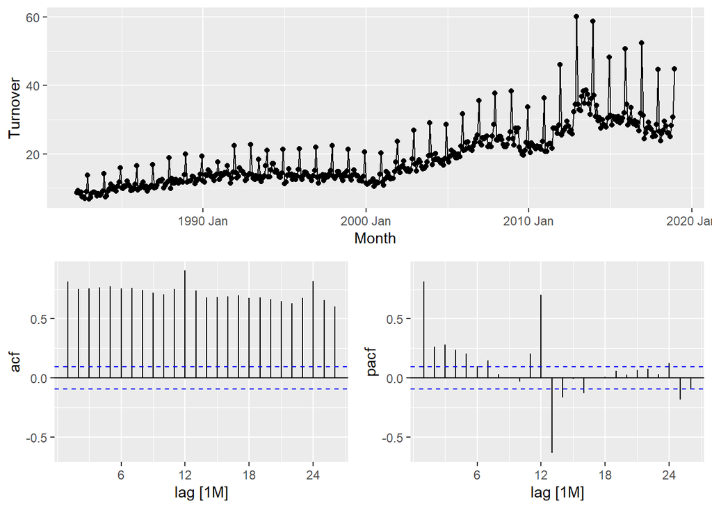

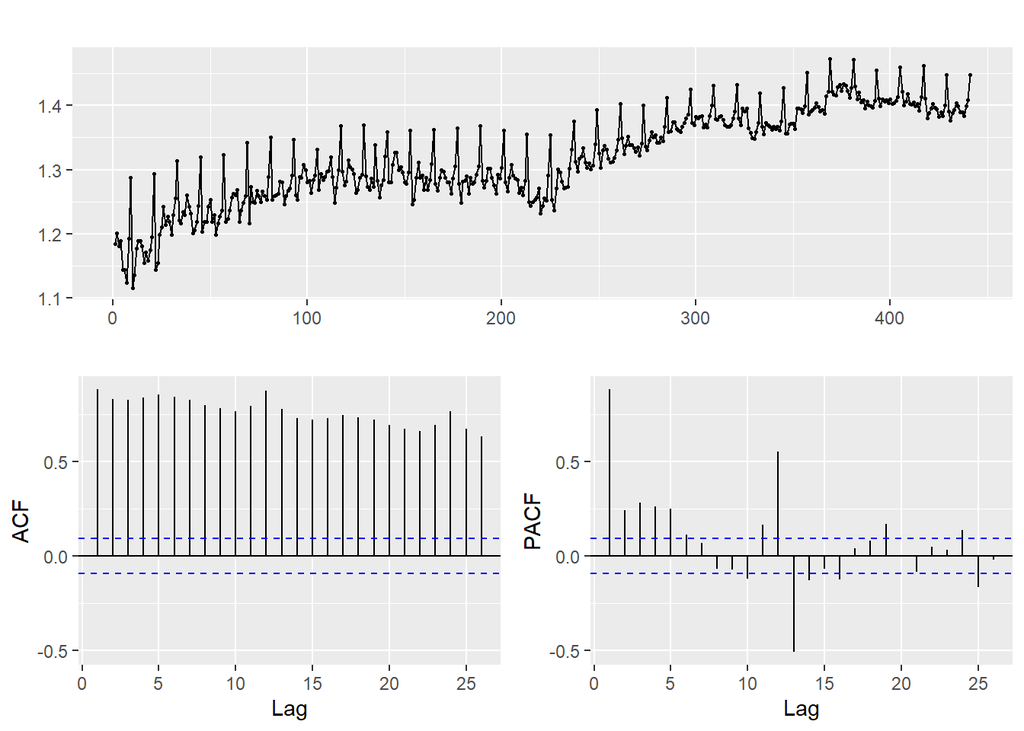

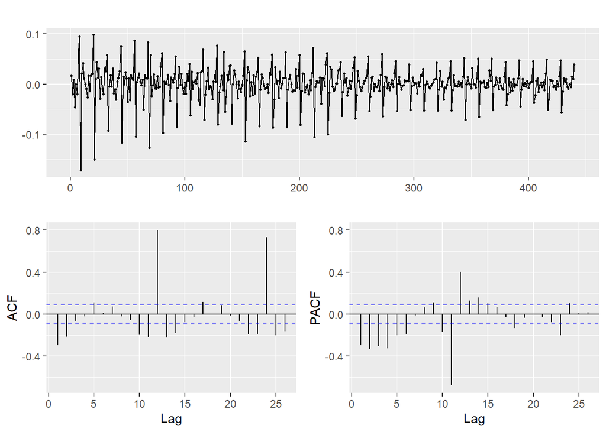

```
##
## #######################
## # KPSS Unit Root Test #
## #######################
##
## Test is of type: mu with 5 lags.
##
## Value of test-statistic is: 0.0141
##
## Critical value for a significance level of:
##                 10pct  5pct 2.5pct  1pct
## critical values 0.347 0.463  0.574 0.739
```

## Exercise 6

Simulate and plot some data from simple ARIMA models.

1. Use the following R code to generate data from an AR(1) model with ϕ1=0.6 and σ2=1. The process starts with y1=0.

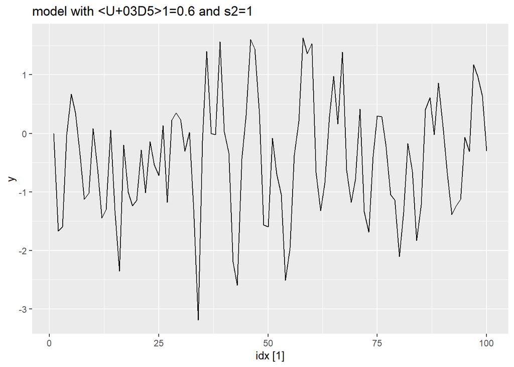

The plot looks stationary

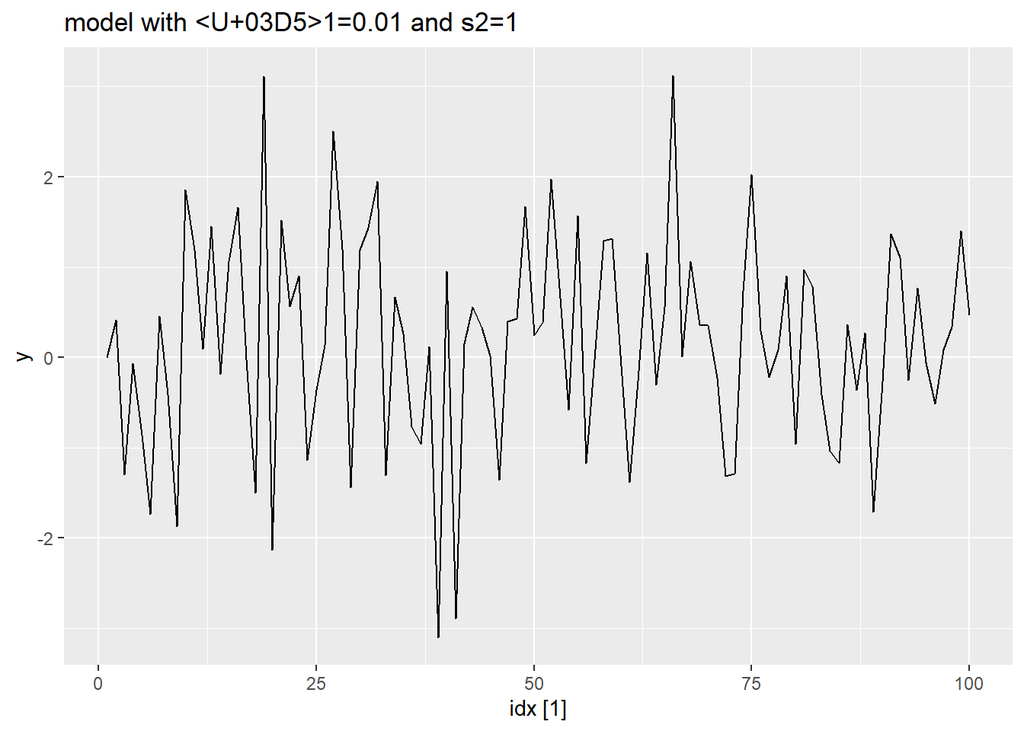

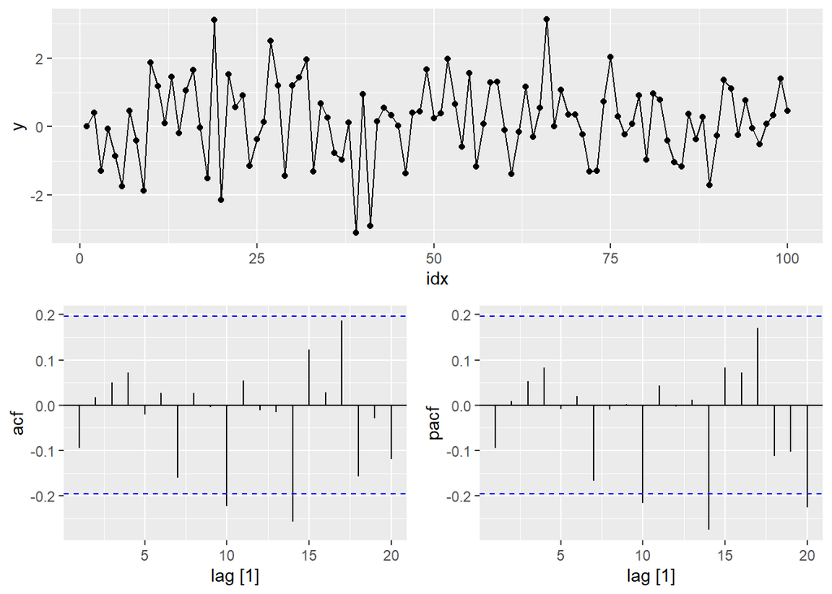

3. Write your own code to generate data from an MA(1) model with θ1=0.6 and σ2=1.
4. Produce a time plot for the series. How does the plot change as you change θ1?

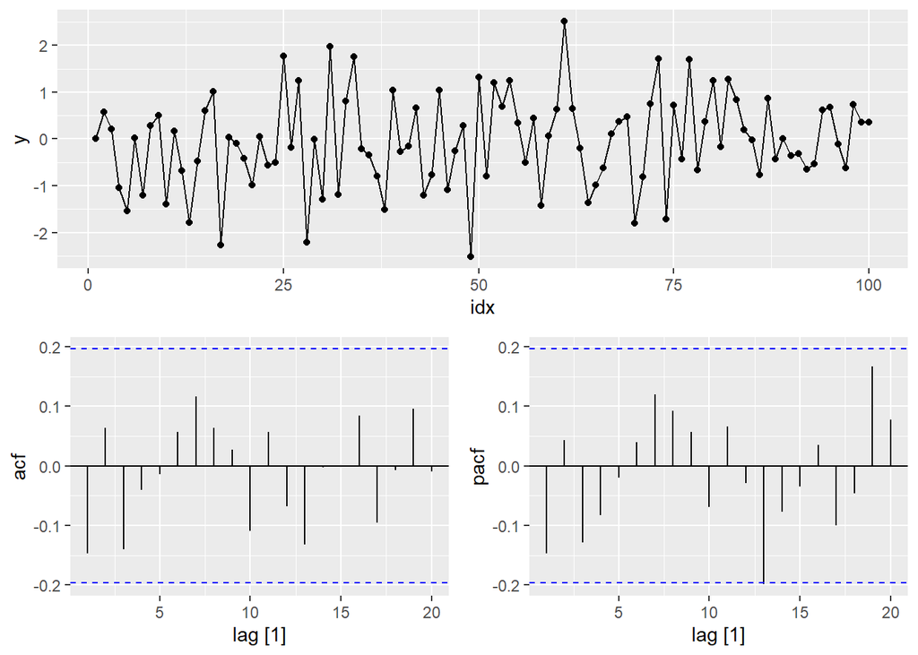

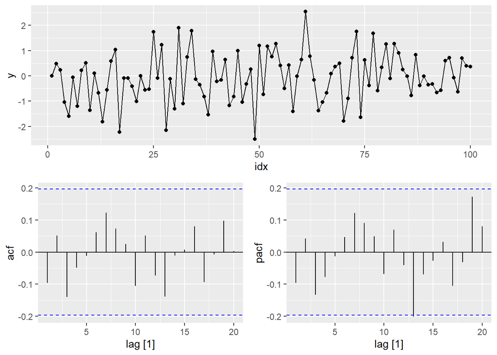

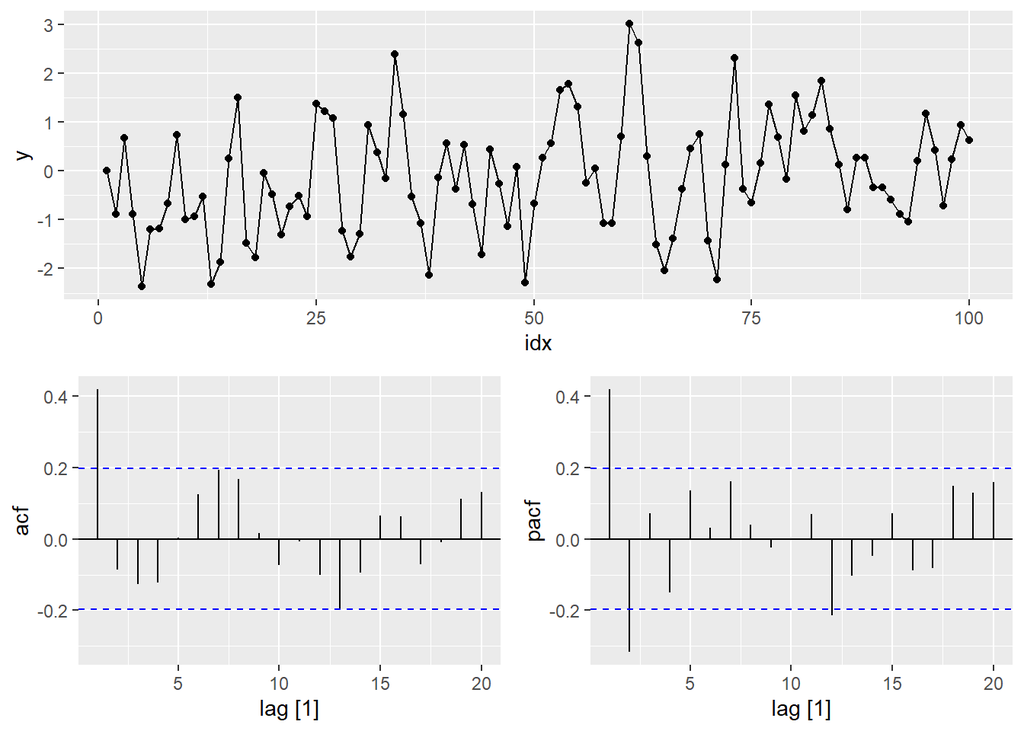

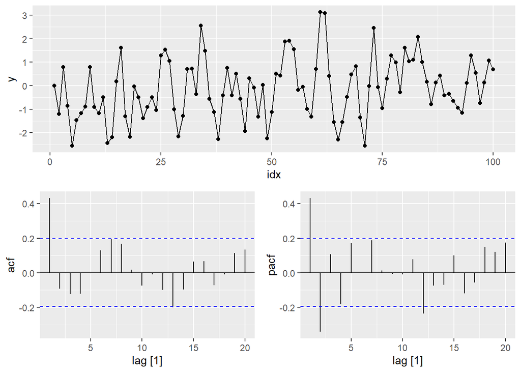

Not much changes on plots than more noise.

5. Generate data from an ARMA(1,1) model with ϕ1=0.6, θ1=0.6 and σ2=1.
6. Generate data from an AR(2) model with ϕ1=−0.8, ϕ2=0.3 and σ2=1. (Note that these parameters will give a non-stationary series.)

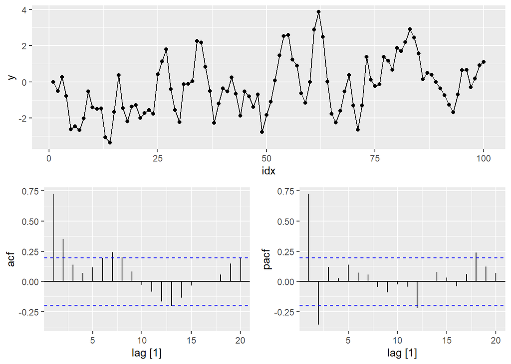

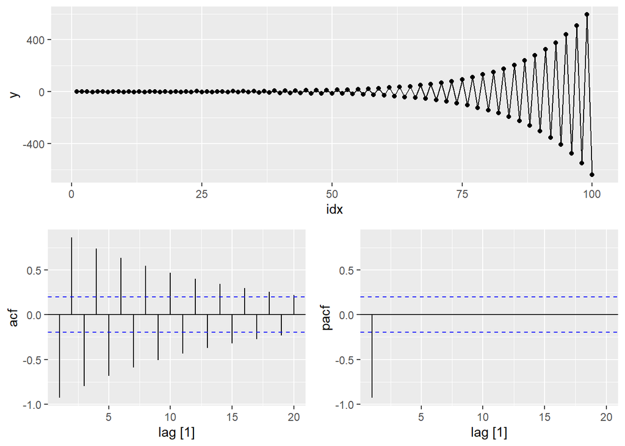

## Exercise 7

Consider aus_airpassengers, the total number of passengers (in millions) from Australian air carriers for the period 1970-2011. a. Use ARIMA() to find an appropriate ARIMA model. What model was selected. Check that the residuals look like white noise. Plot forecasts for the next 10 periods.

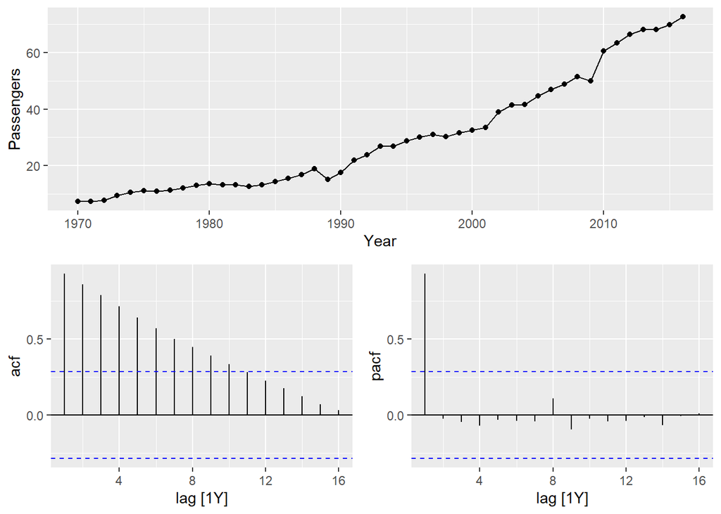

```
## # A tibble: 3 x 8
##   .model   sigma2 log_lik   AIC  AICc   BIC ar_roots  ma_roots
##   <chr>     <dbl>   <dbl> <dbl> <dbl> <dbl> <list>    <list>
## 1 arima      4.31   -97.0  198.  198.  202. <cpl [0]> <cpl [1]>
## 2 stepwise   4.31   -97.0  198.  198.  202. <cpl [0]> <cpl [1]>
## 3 search     4.31   -97.0  198.  198.  202. <cpl [0]> <cpl [1]>
```

```
## # A tibble: 1 x 3
##   .model lb_stat lb_pvalue
##   <chr>    <dbl>     <dbl>
## 1 arima     6.70     0.461
```

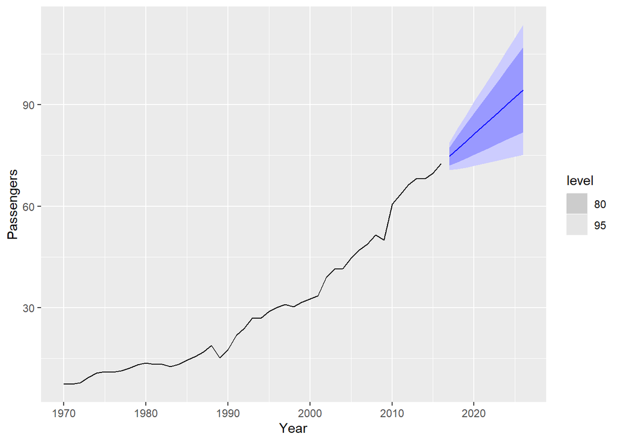

b. Write the model in terms of the backshift operator. c. Plot forecasts from an ARIMA(0,1,0) model with drift and compare these to part a. d. Plot forecasts from an ARIMA(2,1,2) model with drift and compare these to parts a and c. Remove the constant and see what happens. e. Plot forecasts from an ARIMA(0,2,1) model with a constant. What happens?

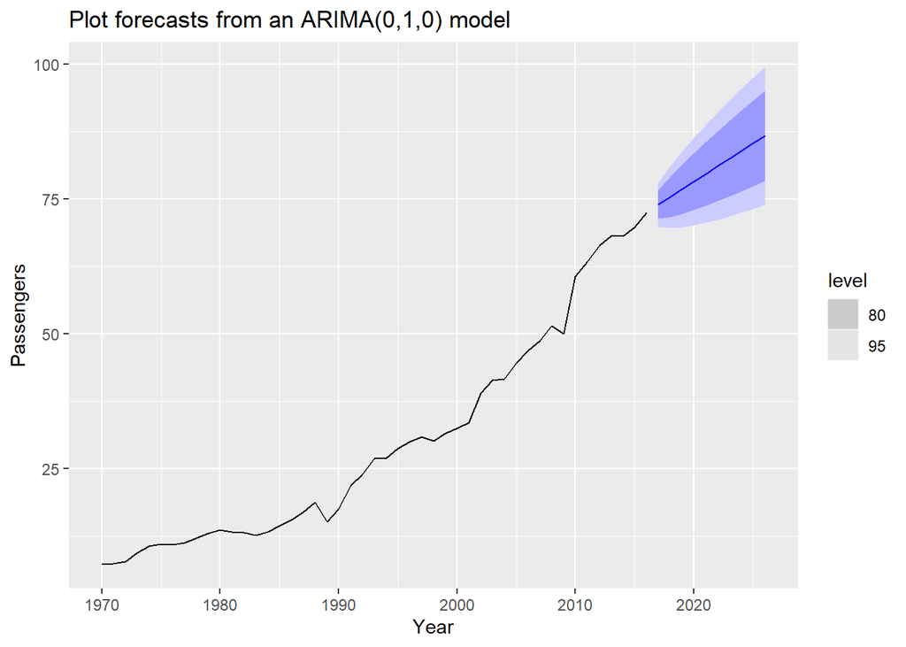

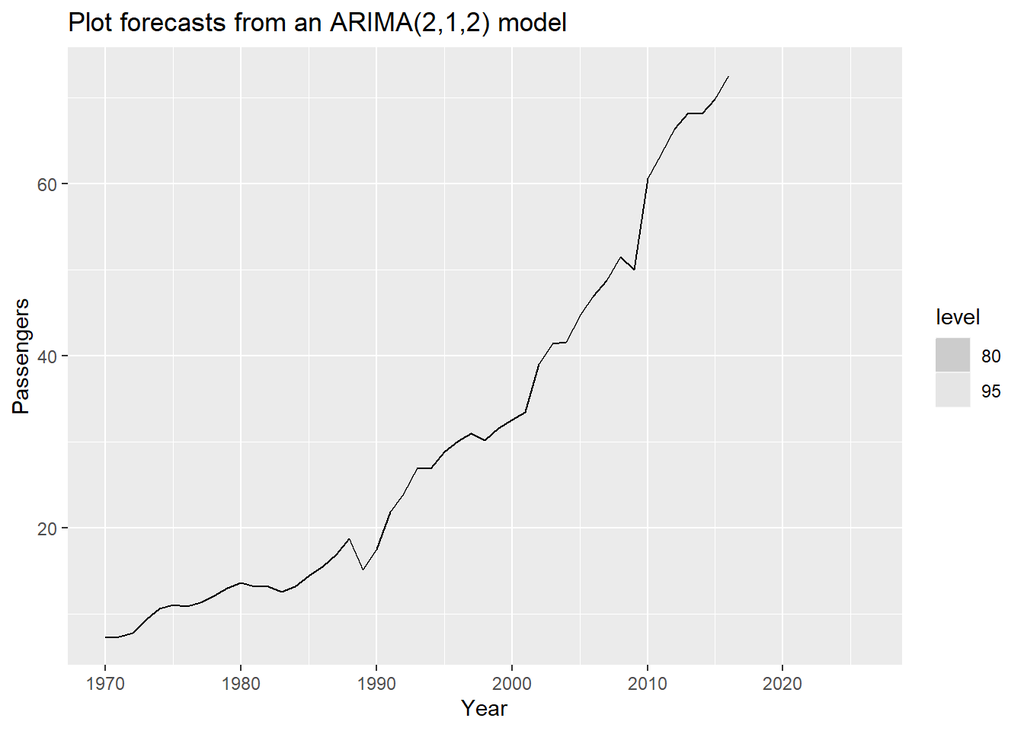

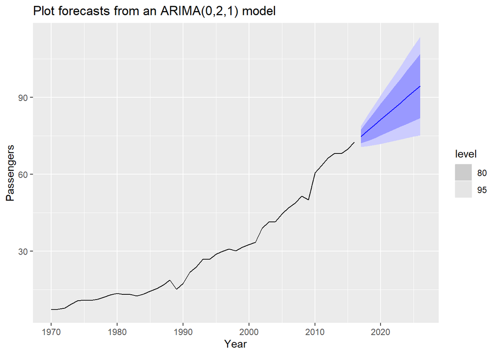

```
## # A tibble: 5 x 8
##   .model   sigma2 log_lik   AIC  AICc   BIC ar_roots  ma_roots
##   <chr>     <dbl>   <dbl> <dbl> <dbl> <dbl> <list>    <list>
## 1 arima      4.31   -97.0  198.  198.  202. <cpl [0]> <cpl [1]>
## 2 arima021   4.31   -97.0  198.  198.  202. <cpl [0]> <cpl [1]>
## 3 stepwise   4.31   -97.0  198.  198.  202. <cpl [0]> <cpl [1]>
## 4 search     4.31   -97.0  198.  198.  202. <cpl [0]> <cpl [1]>
## 5 arima010   4.27   -98.2  200.  201.  204. <cpl [0]> <cpl [0]>
```

```
## # A tibble: 1 x 3
##   .model   lb_stat lb_pvalue
##   <chr>      <dbl>     <dbl>
## 1 arima010    6.77     0.453
```

```
## # A tibble: 1 x 3
##   .model   lb_stat lb_pvalue
##   <chr>      <dbl>     <dbl>
## 1 arima212      NA        NA
```

Amount all fitted model, the ARIMA(2,1,2) returned a null model.